# Lecture_3 - Grammar of Graphics

# Grammar

- standard way of describing graphics
- understanding
- put constraints
- generalization

## Generalization

Components of a graph may be the graphical devices that allow to carry information.

# Elements of the grammar

There are overall 8 components: - DATA Without data you cannot have any data visualization. Data should be: *tidy* - one variable per column - one observation per row - one value per cell

- AESTHETIC MAPPINGS *(Case study is related to wooclap example)*
  - GDP (gross domestic product) -> x axis
  - Continent -> Color
  - Population of country -> Size
  - ….
- GEOMETRIC OBJECTS
  - Circles/Points
  - Lines
  - Polygons
  - Bars
  - ….

> *N.B*: aesthetic variable are properties of geometric objects.
- SCALES map data values to aesthetic values
  - invertible function
- STATISTICAL TRANSFORMATIONS
  - average, median, kernel density estimation, … and so on
  - identity
  - Regression models..
- POSITION ADJUSTMENTS
  - readibility
  - stacked bar chart
- FACETING
  - Many plots from different subsets of the data
- COORDINATE SYSTEM Mapping position of x and y scale to pixel position on the screen.
  - Cartesian coordinate system
  - Polar system

## LAYERS

### Part of the layer

A layer is composed of the following: - Data - Aesthetic mapping - Geom - Stat - Position

### Outside of the layer

- Facet specification
- Coordinate system
- Scales

# Examples

```r
library(gapminder)
library(ggplot2)
library(tidyverse)
```

```r
data <- gapminder::gapminder
```

```r
data |>
  summarize(min(gdpPercap),
            max(gdpPercap),
            min(lifeExp),
            max(lifeExp)
            )
```

| min(gdpPercap) | max(gdpPercap) | min(lifeExp) | max(lifeExp) |
| --- | --- | --- | --- |
| 241.1659 | 113523.1 | 23.599 | 82.603 |

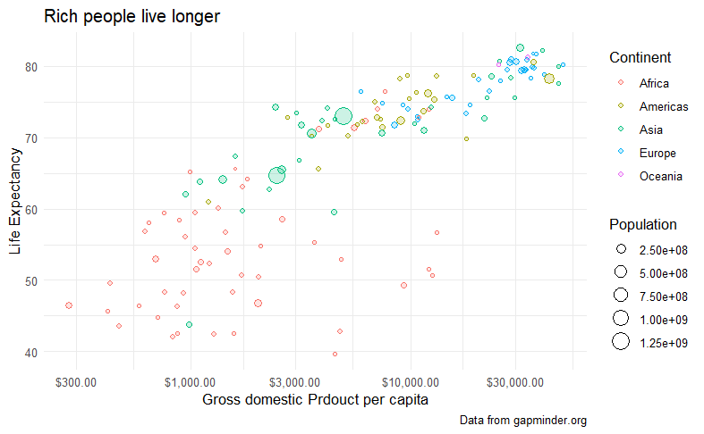

```r
data |>
  filter(year==2007) |>
  ggplot(aes(x=gdpPercap,
             y=lifeExp,
             size=pop,
             color=continent)
         ) +
  geom_point(
    mapping=aes(fill=continent),
    shape=21,
    alpha=0.2
    ) +
  geom_point(shape=21) +
  scale_x_log10(labels=scales::label_dollar()) +
  labs(
    x="Gross domestic Prdouct per capita",
    y="Life Expectancy",
    fill="Continent",
    color="Continent",
    size="Population",
    title="Rich people live longer",
    caption="Data from gapminder.org"
  ) +
  theme_minimal() +
  theme(
    legend.position = "right"
  )
```

# Statistical summaries

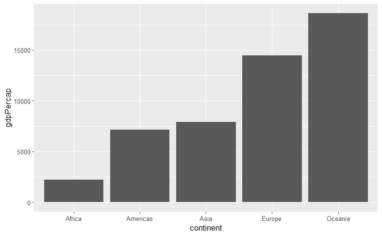

```r
data |>
  group_by(continent) |>
  summarise(gdpPercap=mean(gdpPercap)) |>
  ggplot(aes(x=continent,y=gdpPercap)) +
  geom_col()
```

[figure not shown]

```r
ggplot(gapminder,
       aes(x=continent,y=gdpPercap)) +
  geom_point(alpha=0.2, size=0.5, position = position_jitter()) +
  stat_summary(
    fun.data=mean_cl_boot,
    color="red",
    geom="linerange"
  ) +
  scale_y_log10() +
  theme_minimal()
```